# Figure 3b

miR34a asRNA stable cell line cell cycle

Jason T. Serviss

31/01/2017

```r
projectUrl <- "https://github.com/GranderLab/miR34a_asRNA_project/raw/master/inst/"
dataUrl <- "https://github.com/GranderLab/miR34a_asRNA_project/raw/master/data"
```

#### *Introduction*

miR34a is known to regulate cell cycle and, specifically, induce G1-phase arrest. Due to the increase observed in miR34a expression levels in cell lines over-expressing miR34a asRNA, we investigated if the cell cycle was perturbed in these cells.

#### *Methods*

*Cell culture and cell cycle analysis*

All cell lines were cultured at 5% CO2 and 37° C with Skov3 and PC3 cells in RPMI (Hyclone) and 2 mM L-glutamine. All growth mediums were supplemented with 10% heat-inactivated FBS and 50 μg/ml of streptomycin and 50 μg/ml of penicillin. 1x10^5 cells per well in a 6-well plate and harvested after 24hrs. Cells were washed in PBS and fixed in 4% PFA at room temperature overnight. PFA was removed, and cells were resuspended in 95% EtOH. The samples were then rehydrated in distilled water, stained with DAPI and analyzed by flow cytometry on a LSRII (BD Biosciences) machine.

Percentages were converted to log2 fractions for each sample. Student’s t-test was used for statistical analysis comparing the mock vs miR34a asRNA overespression conditions using five (PC3) or three (Skov3) independant experiments.

#### *Results*

```r
url <- "figure3b_stableLineCellCycle.rds"
data <- read_rds(gzcon(url(file.path(dataUrl, url))))

#convert the value (precent) to log2(fraction)
data <- mutate(data, value = log2(value / 100))

#qqplot shows that the data is reasonably normal. The shapiro test is also used below. Note that a p < 0.05 indicates non-normality.
#qqnorm(data$value)

#calculate stats
stats <- data %>%
  full_join(
    filter(data, condition == "mock"),
    by = c("Biological Replicate", "Cell line", "phase"),
    suffix = c("", ".y")
  ) %>%
  group_by(`Cell line`, condition, phase) %>%
  summarize(
    n = n(),
    mean = (2^mean(.data$value)),
    max = (2^max(.data$value)),
    CI95l = (2^t.test(.data$value)$conf.int[1]),
    CI95h = (2^t.test(.data$value)$conf.int[2]),
    pValue = t.test(.data$value, .data$value.y)$p.value,
    shapiroTest = shapiro.test(value)$p.value
  ) %>%
  ungroup() %>%
  pFormat(.)

#prepare for plotting
#change value back to percent
data <- data %>%
  mutate(value = 2^value)

#calculate start and end for horizontal plot lines
stats <- stats %>%
  group_by(phase, `Cell line`) %>%
  mutate(y = max(c(.data$CI95h, .data$max))) %>%
  ungroup() %>%
  arrange(`Cell line`, phase) %>%
  mutate(
    x = rep(sort(rep(1:3, 2)), 2) - 0.25,
    xend = rep(sort(rep(1:3, 2)), 2) + 0.25
  )
```

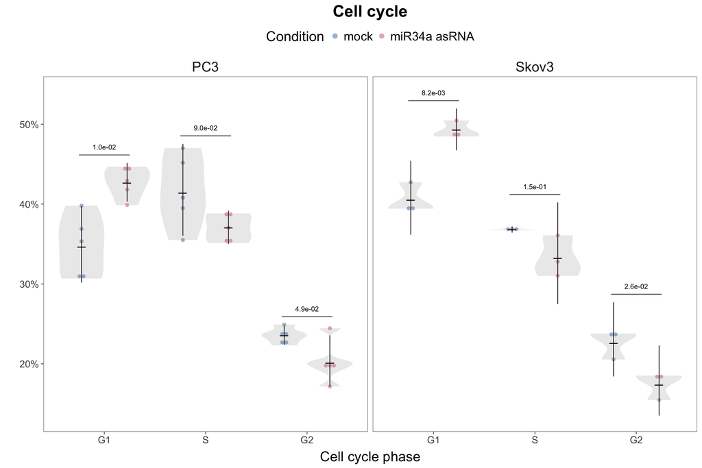

```r
p <- ggplot(data = NULL) +
  geom_violin(
    data = data,
    aes(
      x = phase,
      y = value,
      group = interaction(phase, condition)
    ),
    scale = "width",
    alpha = 0.3,
    fill = "gray",
    weight = 10,
    trim = TRUE,
    color = NA,
    show.legend = FALSE
  ) +
  geom_dotplot(
    data = data,
    aes(
      x = phase,
      y = value,
      fill = condition
    ),
    binwidth = 1/100,
    colour = NA,
    alpha = 0.5,
    position = position_dodge(width = 0.9),
    binaxis = 'y',
    stackdir = 'center',
    dotsize = 0.5,
    show.legend = TRUE
  ) +
  facet_grid(
    . ~ `Cell line`,
    scale = "free"
  ) +
  scale_y_continuous(labels = scales::percent_format()) +
  labs(
    x = "Cell cycle phase",
    y = "",
    title = "Cell cycle"
  )

markdown <- p +
  geom_linerange(
    data = stats,
    aes(
      x = phase,
      ymin = CI95l,
      ymax = CI95h,
      group = interaction(phase, condition)
    ),
    position = position_dodge(width = 0.9),
    colour = "grey25",
    show.legend = FALSE
  ) +
  geom_point(
    data = stats,
    aes(
      x = phase,
      y = mean,
      group = condition
    ),
    colour = "black",
    position = position_dodge(width = 0.9),
    shape = 95,
    size = 6,
    show.legend = FALSE
  ) +
  geom_segment(
    data = stats,
    aes(
      x = x,
      y = y + 0.01,
      xend = xend,
      yend = y + 0.01
    ),
    colour = "grey43",
    show.legend = FALSE
  ) +
  geom_label(
    data = stats,
    aes(
      x = phase,
      y = y + 0.02,
      label = pFormat
    ),
    label.size = 0,
    label.padding = unit(0.01, "lines"),
    show.legend = FALSE,
    fill = "white",
    size = 3,
    family = "Arial Unicode MS"
  ) +
  guides(
    fill = guide_legend(
      title = "Condition",
      override.aes = list(size = 6)
    )
  )

plotRmarkdown(markdown)
```

```r
pdf <- p +
  geom_linerange(
    data = stats,
    aes(
      x = phase,
      ymin = CI95l,
      ymax = CI95h,
      group = interaction(phase, condition)
    ),
    position = position_dodge(width = 0.9),
    colour = "grey25",
    size = 0.1,
    show.legend = FALSE
  ) +
  geom_point(
    data = stats,
    aes(
      x = phase,
      y = mean,
      group = condition
    ),
    colour = "black",
    position = position_dodge(width = 0.9),
    shape = 95,
    show.legend = FALSE
  ) +
  geom_segment(
    data = stats,
    aes(
      x = x,
      y = y + 0.01,
      xend = xend,
      yend = y + 0.01
    ),
    colour = "grey43",
    size = 0.1,
    show.legend = FALSE
  ) +
  geom_label(
    data = stats,
    aes(
      x = phase,
      y = y + 0.025,
      label = pFormat
    ),
    label.size = 0,
    label.padding = unit(0.01, "lines"),
    show.legend = FALSE,
    fill = "white",
    size = 1.5,
    family = "Arial Unicode MS"
  ) +
  guides(
    fill = guide_legend(
      title = "Condition",
      override.aes = list(size = 4)
    )
  )

figure <- plotPDF(pdf)
path <- "~/GitHub/miR34a_asRNA_project/inst/figure3b_stableLineCellCycle/figure3b_stableLineCellCycle.pdf"

ggsave(
   plot = figure,
   filename = path,
   device = cairo_pdf,
   height = 60,
   width = 83,
   units = "mm"
)
```

#### *Conclusion*

An increase in the percentage of cells in G1-phase can be seen in cell lines overexpressing miR34a asRNA. In addition, a concominant decrease of cells in G2-phase can be observed.